# Práctica 5 - Ejercicio 5

Los datos que se muestran en el archivo salud.txt corresponden a 30 miembros de un club de salud. Las variables son:

- X1= peso en libras
- X2= pulso en reposo
- X3= fuerza del brazo y pierna (n ́umero de libras que puede levantar)
- X4= tiempo en segundos en que corre 1/4 de milla
- Y= tiempo en segundos en que corre 1 milla

# Item a

1. Estime por cuadrados mínimos los parámetros del modelo:
   $$Y = \beta_0 + \beta_1 X_1 + \beta_2 X_2 + \beta_3 X_3 + \beta_4 X_4$$
2. Realice el gráfico de los residuos estandarizados versus Y, y el QQ–plot de los residuos.
3. Hay algún indicio de que haya groseras violaciones de supuestos?

```r
df = read.table("~/code/Modelo_Lineal_2019/ejercicios/salud.txt", header=T)

reg1 = lm(df$Y~., data=df)
summary(reg1)
```

```
##
## Call:
## lm(formula = df$Y ~ ., data = df)
##
## Residuals:
##     Min      1Q  Median      3Q     Max
## -54.163 -18.932  -5.549  18.916  44.802
##
## Coefficients:
##             Estimate Std. Error t value Pr(>|t|)
## (Intercept) -0.62555   62.54048  -0.010 0.992102
## obs         -0.08044    0.67701  -0.119 0.906412
## X1           1.27781    0.30499   4.190 0.000326 ***
## X2          -0.53977    0.88881  -0.607 0.549359
## X3          -0.50708    0.25151  -2.016 0.055114 .
## X4           3.87242    0.80520   4.809 6.74e-05 ***
## ---
## Signif. codes:  0 '***' 0.001 '**' 0.01 '*' 0.05 '.' 0.1 ' ' 1
##
## Residual standard error: 29.25 on 24 degrees of freedom
## Multiple R-squared:  0.8532, Adjusted R-squared:  0.8226
## F-statistic:  27.9 on 5 and 24 DF,  p-value: 2.92e-09
```

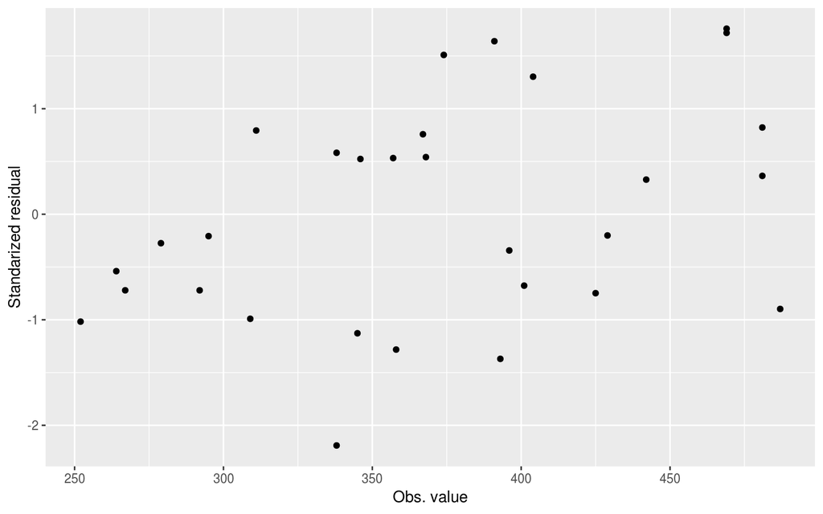

```r
ggplot(df, aes(x=df$Y, y=rstandard(reg1))) + geom_point() + ylab("Standarized residual") + xlab("Obs. value")
```

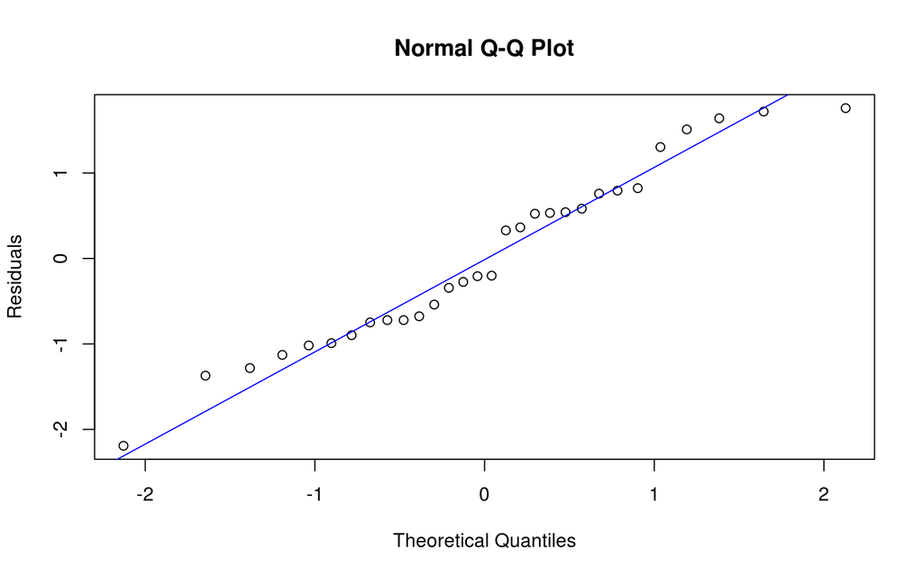

```r
qqnorm(rstandard(reg1), ylab="Residuals")
qqline(rstandard(reg1), col="blue")
```

- El qqplot de residuos estandarizados presenta cierta estructura: los puntos parecen seguir una oscilación alrededor de la recta identidad. No parece ser grosera la violación del supuesto de normalidad, sobre todo porque no se observan “colas pesadas”.

# Item b

Realice un boxplot para los residuos estandarizados. ¿A qué número de observación corresponde el residuo de mayor valor absoluto?

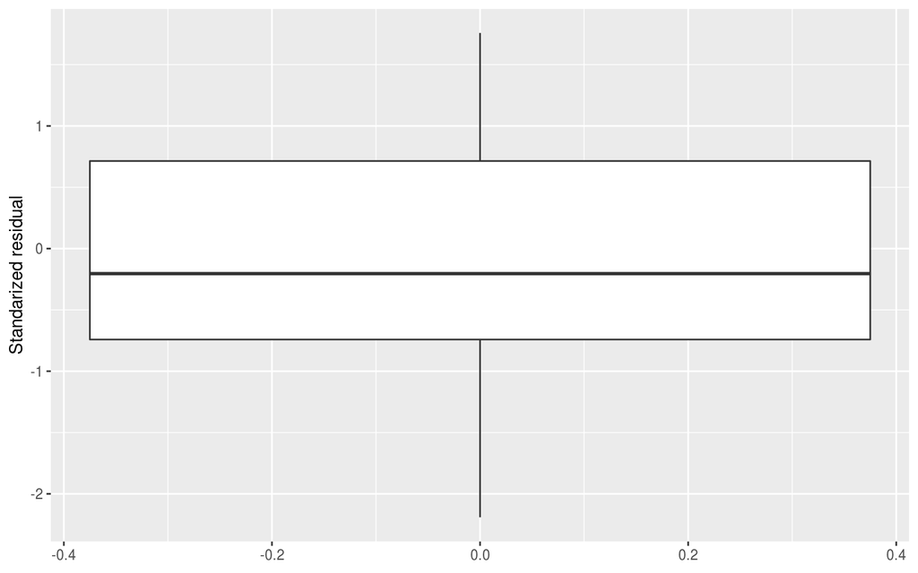

```r
ggplot(df, aes(y=rstandard(reg1))) +  geom_boxplot() +  ylab("Standarized residual")
```

```r
max_stdres_index = which.max(abs(rstandard(reg1)))
```

# Item c

- Calcule el leverage de cada observación y realice un boxplot.
- ¿Cuál es la observación con mayor leverage?
- Use los criterios dados para identificar aquellas observaciones cuyo leverage puede indicar problemas.

### Boxplot y resumen de las medidas de diagnóstico

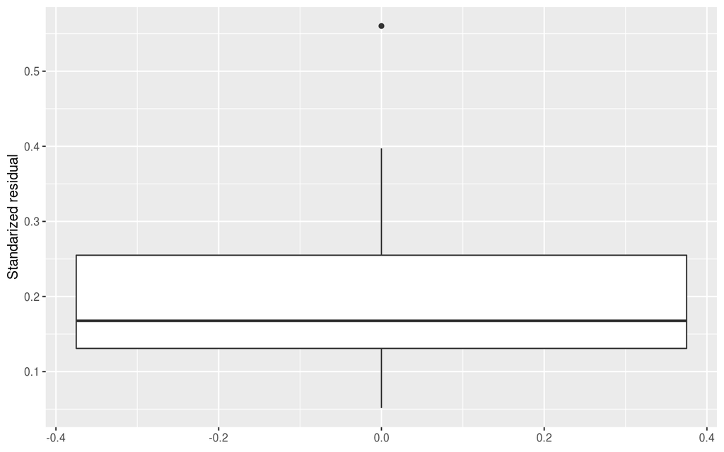

```r
X = model.matrix(reg1)
P = X %*% solve(t(X) %*% X) %*% t(X)
leverages = diag(P)
ggplot(df, aes(y=leverages)) +  geom_boxplot() +  ylab("Standarized residual")
```

```r
df_diagnosis = data.frame(leverages=leverages, stud_res=MASS::studres(reg1), cook_d=cooks.distance(reg1), residuals=residuals(reg1))
kable(summary(df_diagnosis))
```

|  | leverages | stud_res | cook_d | residuals |
| --- | --- | --- | --- | --- |
|  | Min. :0.05147 | Min. :-2.398419 | Min. :0.00107 | Min. :-54.163 |
|  | 1st Qu.:0.13087 | 1st Qu.:-0.734183 | 1st Qu.:0.00660 | 1st Qu.:-18.932 |
|  | Median :0.16765 | Median :-0.200106 | Median :0.02160 | Median : -5.549 |
|  | Mean :0.20000 | Mean :-0.003533 | Mean :0.05591 | Mean : 0.000 |
|  | 3rd Qu.:0.25498 | 3rd Qu.: 0.706967 | 3rd Qu.:0.05742 | 3rd Qu.: 18.916 |
|  | Max. :0.56021 | Max. : 1.844602 | Max. :0.33974 | Max. : 44.802 |

```r
kable(df_diagnosis[order(df_diagnosis$leverages, decreasing=T)[1:5], ])
```

|  | leverages | stud_res | cook_d | residuals |
| --- | --- | --- | --- | --- |
| 23 | 0.5602052 | -0.8938725 | 0.1710603 | -17.414612 |
| 28 | 0.3972507 | 1.8446021 | 0.3397406 | 39.942999 |
| 13 | 0.3445599 | -0.2690200 | 0.0065958 | -6.498266 |
| 1 | 0.3061387 | 0.8164356 | 0.0497066 | 20.034718 |
| 30 | 0.2860893 | -2.3984187 | 0.3206960 | -54.162961 |

```r
kable(df_diagnosis[order(df_diagnosis$leverages, decreasing=T)[1:10], ])
```

|  | leverages | stud_res | cook_d | residuals |
| --- | --- | --- | --- | --- |
| 23 | 0.5602052 | -0.8938725 | 0.1710603 | -17.414612 |
| 28 | 0.3972507 | 1.8446021 | 0.3397406 | 39.942999 |
| 13 | 0.3445599 | -0.2690200 | 0.0065958 | -6.498266 |
| 1 | 0.3061387 | 0.8164356 | 0.0497066 | 20.034718 |
| 30 | 0.2860893 | -2.3984187 | 0.3206960 | -54.162961 |
| 11 | 0.2760158 | -1.3974837 | 0.1193538 | -34.114802 |
| 18 | 0.2691795 | 0.3219871 | 0.0066113 | 8.207217 |
| 29 | 0.2552914 | -1.0182948 | 0.0591532 | -25.687385 |
| 17 | 0.2540551 | 1.3236675 | 0.0964333 | 32.932060 |
| 16 | 0.2340032 | -0.7135062 | 0.0264615 | -18.458055 |

# Item d

- Calcule la distancia de Cook para cada observación y realice un boxplot.
- ¿Cuáles son los cuatro puntos que aparecen como outliers en este gráfico?
- ¿Cuál es la observación de mayor influencia?
- ¿Qué pasa con el leverage de observación?

### Ordenamos las medidas de diagnóstico por distancia de Cook

```r
writeLines("td, th { padding : 6px } th { background-color : brown ; color : white; border : 1px solid white; } td { color : brown ; border : 1px solid brown }", con = "mystyle.css")
kable(df_diagnosis[order(df_diagnosis$cook_d, decreasing=T)[1:10], ])
```

|  | leverages | stud_res | cook_d | residuals |
| --- | --- | --- | --- | --- |
| 28 | 0.3972507 | 1.8446021 | 0.3397406 | 39.94300 |
| 30 | 0.2860893 | -2.3984187 | 0.3206960 | -54.16296 |
| 23 | 0.5602052 | -0.8938725 | 0.1710603 | -17.41461 |
| 8 | 0.2213774 | 1.7966202 | 0.1399639 | 44.36404 |
| 11 | 0.2760158 | -1.3974837 | 0.1193538 | -34.11480 |
| 17 | 0.2540551 | 1.3236675 | 0.0964333 | 32.93206 |
| 21 | 0.1275816 | 1.7033668 | 0.0655262 | 44.80238 |
| 29 | 0.2552914 | -1.0182948 | 0.0591532 | -25.68738 |
| 25 | 0.1208333 | 1.5534414 | 0.0522043 | 41.40889 |
| 1 | 0.3061387 | 0.8164356 | 0.0497066 | 20.03472 |

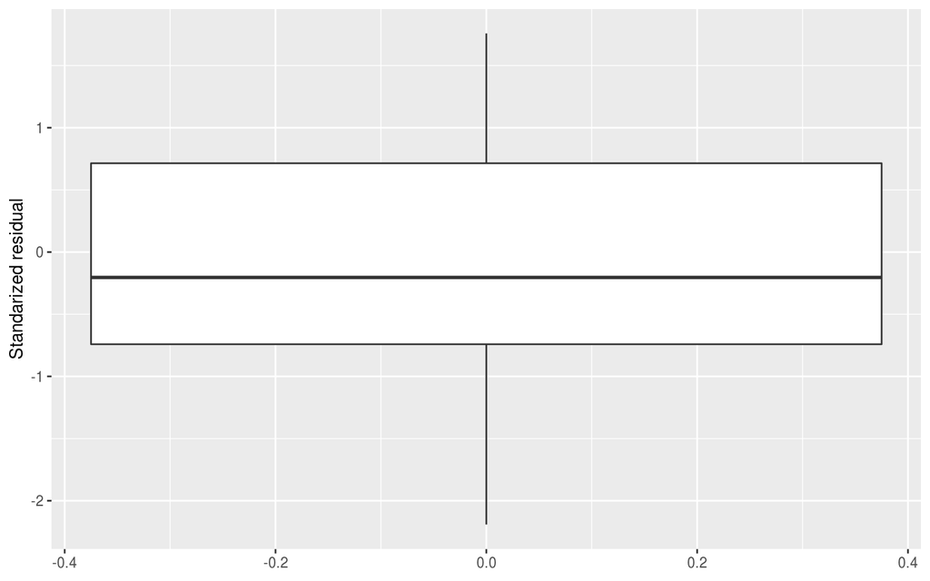

```r
# Boxplot
ggplot(df, aes(y=rstandard(reg1))) +  geom_boxplot() +  ylab("Standarized residual")
```

### Residuos estudentizados vs. leverage

La escala de colores está asociada a la distancia de cook. La etiqueta numérica es el índice del dato en el conjunto de datos original.

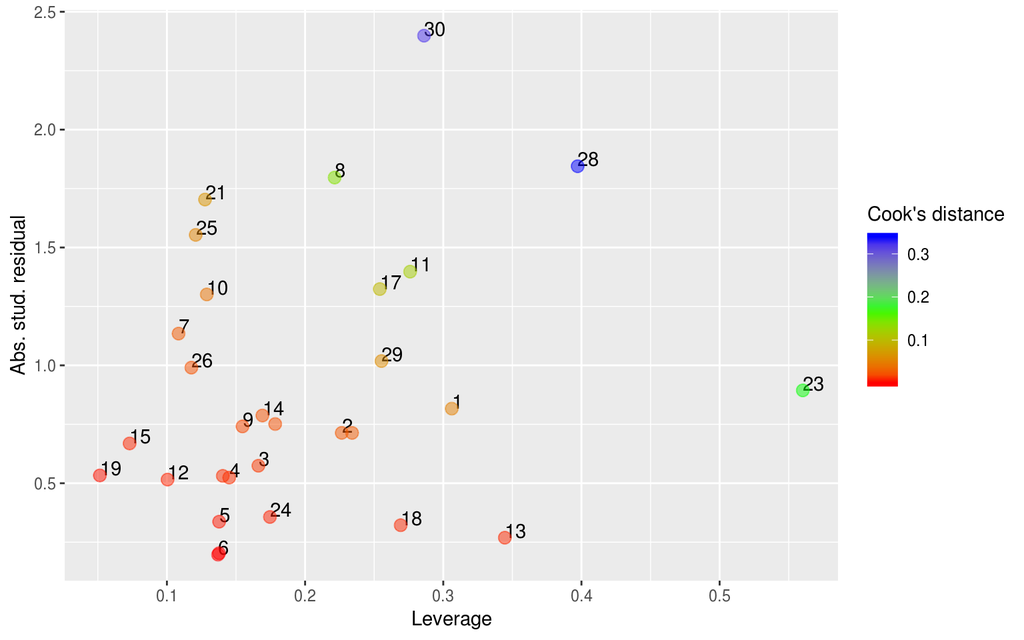

```r
# Residuals and cook distance
ggplot(data=df) +
  scale_colour_gradientn(colours=rainbow(3)) +
  geom_text(aes(label=1:nrow(df_diagnosis)), hjust=0, vjust=0, color="black", show.legend = F, check_overlap = T) +
  aes(x=df_diagnosis$leverages, y=abs(df_diagnosis$stud_res), color=df_diagnosis$cook_d) +
  geom_point(alpha=0.5, size=3) +
  labs(color="Cook's distance", x="Leverage", y="Abs. stud. residual")
```

# Item e

Repita los ́ıtems a) y b) pero realizando un ajuste robusto. ¿Qué observa?

```r
reg2 = rlm(df$Y~., data=df, method="MM", psi=psi.bisquare, maxit=100)
reg3 = rlm(df$Y~., data=df, method="MM", maxit=100)

summary(reg1)
```

```
##
## Call:
## lm(formula = df$Y ~ ., data = df)
##
## Residuals:
##     Min      1Q  Median      3Q     Max
## -54.163 -18.932  -5.549  18.916  44.802
##
## Coefficients:
##             Estimate Std. Error t value Pr(>|t|)
## (Intercept) -0.62555   62.54048  -0.010 0.992102
## obs         -0.08044    0.67701  -0.119 0.906412
## X1           1.27781    0.30499   4.190 0.000326 ***
## X2          -0.53977    0.88881  -0.607 0.549359
## X3          -0.50708    0.25151  -2.016 0.055114 .
## X4           3.87242    0.80520   4.809 6.74e-05 ***
## ---
## Signif. codes:  0 '***' 0.001 '**' 0.01 '*' 0.05 '.' 0.1 ' ' 1
##
## Residual standard error: 29.25 on 24 degrees of freedom
## Multiple R-squared:  0.8532, Adjusted R-squared:  0.8226
## F-statistic:  27.9 on 5 and 24 DF,  p-value: 2.92e-09
```

```r
summary(reg2)
```

```
##
## Call: rlm(formula = df$Y ~ ., data = df, psi = psi.bisquare, maxit = 100,
##     method = "MM")
## Residuals:
##     Min      1Q  Median      3Q     Max
## -56.664 -18.881  -5.541  18.987  45.906
##
## Coefficients:
##             Value   Std. Error t value
## (Intercept)  3.1225 67.7443     0.0461
## obs         -0.0324  0.7333    -0.0442
## X1           1.2853  0.3304     3.8906
## X2          -0.6838  0.9628    -0.7102
## X3          -0.5198  0.2724    -1.9081
## X4           3.9518  0.8722     4.5309
##
## Residual standard error: 30.36 on 24 degrees of freedom
```

```r
summary(reg3)
```

```
##
## Call: rlm(formula = df$Y ~ ., data = df, maxit = 100, method = "MM")
## Residuals:
##     Min      1Q  Median      3Q     Max
## -56.664 -18.881  -5.541  18.987  45.906
##
## Coefficients:
##             Value   Std. Error t value
## (Intercept)  3.1225 67.7443     0.0461
## obs         -0.0324  0.7333    -0.0442
## X1           1.2853  0.3304     3.8906
## X2          -0.6838  0.9628    -0.7102
## X3          -0.5198  0.2724    -1.9081
## X4           3.9518  0.8722     4.5309
##
## Residual standard error: 30.36 on 24 degrees of freedom
```

### Item a revisitado

```r
standarize_residuals = function(reg) {
  X = model.matrix(reg3)
  P = X %*% solve(t(X) %*% X) %*% t(X)
  leverages = diag(P)


}

sapply(resid(reg3), function(x){x}, simplify="array")
```

```
##          1          2          3          4          5          6
##  20.356604 -18.778419  16.072574  14.151750  -9.101811  -4.959775
##          7          8          9         10         11         12
## -30.928371  45.905535 -18.937028 -33.949694 -33.676009  15.520805
##         13         14         15         16         17         18
##  -6.166139  22.642522 -18.915633 -16.552453  31.003401   8.987695
##         19         20         21         22         23         24
##  14.864453  -6.123163  43.275533 -14.098333 -18.601743   9.567848
##         25         26         27         28         29         30
##  40.362082 -28.173762  19.957821  40.400221 -25.112187 -56.663685
```

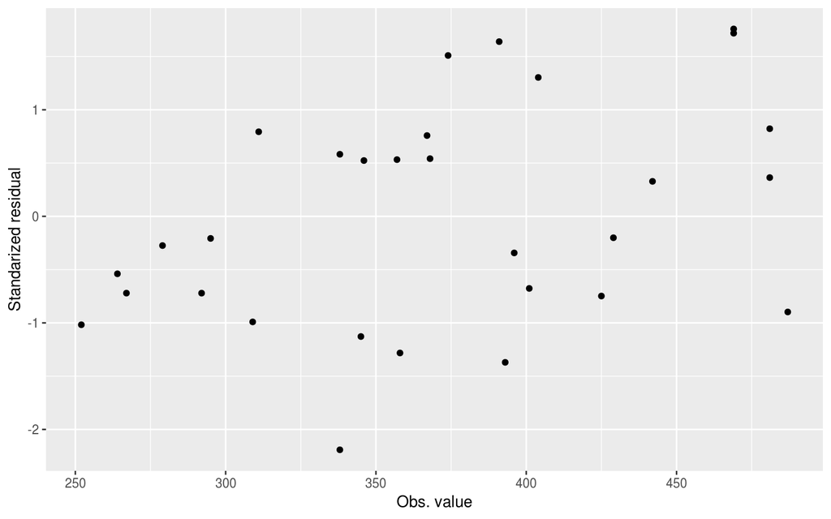

```r
ggplot(df, aes(x=df$Y, y=rstandard(reg1))) + geom_point() + ylab("Standarized residual") + xlab("Obs. value")
```

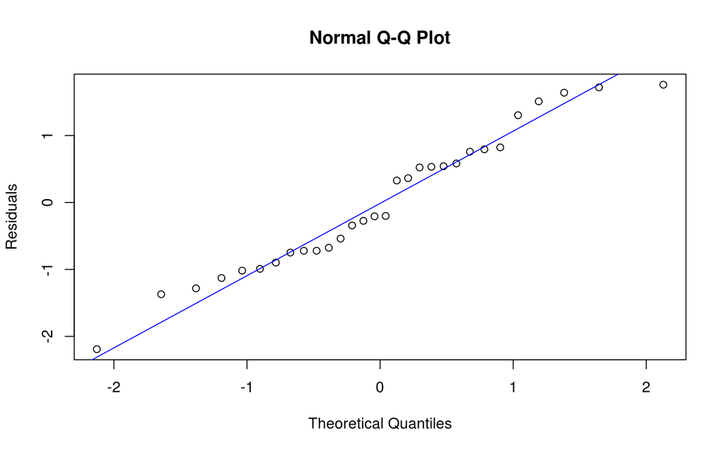

```r
qqnorm(rstandard(reg1), ylab="Residuals")
qqline(rstandard(reg1), col="blue")
```

# Item f

Realice un ajuste de minimos cuadrados generalizados utilizando los pesos que devuelve el ajuste robusto. Compare las estimaciones.

```r
reg_compare = fit.models(c("rlm", "lm"), df$Y~., data=df)
summary(reg_compare)
```

```
##     Length Class Mode
## rlm 21     rlm   list
## lm  12     lm    list
```

```r
reg_compare
```

```
## $rlm
## Call:
## rlm(formula = df$Y ~ ., data = df)
## Converged in 9 iterations
##
## Coefficients:
## (Intercept)         obs          X1          X2          X3          X4
##  8.19225720  0.07284411  1.29416776 -0.83755666 -0.53758106  4.02469472
##
## Degrees of freedom: 30 total; 24 residual
## Scale estimate: 28
##
## $lm
##
## Call:
## lm(formula = df$Y ~ ., data = df)
##
## Coefficients:
## (Intercept)          obs           X1           X2           X3
##    -0.62555     -0.08044      1.27781     -0.53977     -0.50708
##          X4
##     3.87242
```

# Item G

Realice el L–R plot correspondiente a este problema. ¿C ́omo caracterizar ́ıa a lospuntos correspondientes a las observaciones 23, 28 y 30?

### $a^2$ vs. leverage

La escala de colores está asociada a la distancia de cook. La etiqueta numérica es el índice del dato en el conjunto de datos original.

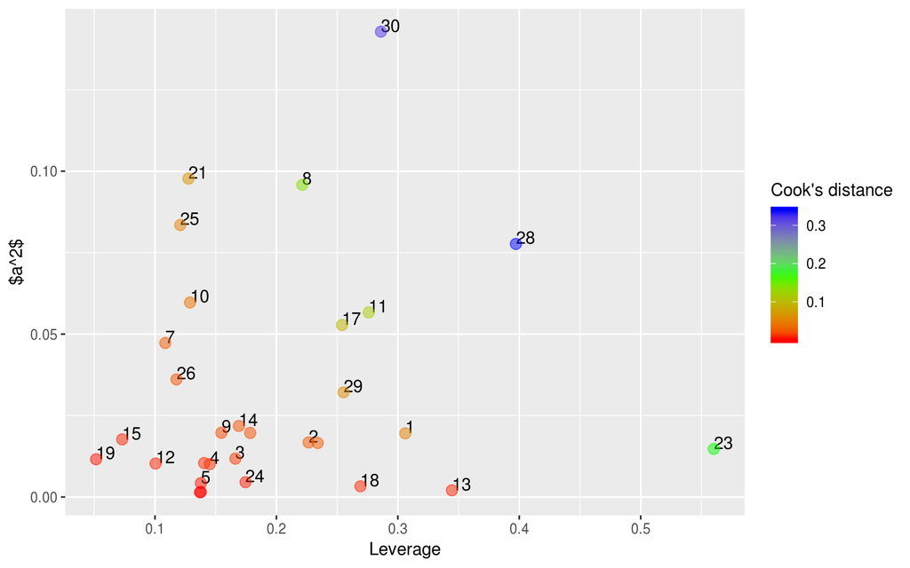

```r
a_squared = resid(reg1)^2 / t(resid(reg1)) %*% resid(reg1)


ggplot(data=df) +
  scale_colour_gradientn(colours=rainbow(3)) +
  geom_text(aes(label=1:nrow(df_diagnosis)), hjust=0, vjust=0, color="black", show.legend = F, check_overlap = T) +
  aes(x=df_diagnosis$leverages, y=a_squared, color=df_diagnosis$cook_d) +
  geom_point(alpha=0.5, size=3) +
  labs(color="Cook's distance", x="Leverage", y="$a^2$")
```

- Dato 23: tiene mucho leverage pero poco residuo. Podría caracterizarlo como un punto lejano al “centro de gravedad” de los datos, pero bien explicado por el modelo lineal. La distancia de Cook es de las más grandes
- Dato 30: tiene mucho resido y es uno de los que más leverage tiene.
- Dato 28: gran leverage y distancia de cook, claramente tiene alta influencia. Tiene uno de los residuos más altos, sería un buen candidato a una examinación pro outliers.

obs: en item d hay un gráfico muy parecido

Mariano Barraco marianobarraco@gmail.com

2019-06-30